# Lesson 3

### What to Do First?

Notes: Install and load the ggplot2 library by writing the following code: install.packages(‘ggplot2’, dependecies = T) library(ggplot2) ***

### Pseudo-Facebook User Data

Notes: This data is generated from a model by Udacity that mimics Facebook data but is not directly from Facebook. We will load the data into R.

```r
setwd('~/Documents/Programming/Data_Analyst/Project_4/EDA_Course_Materials/lesson3')
pf <- read.csv('pseudo_facebook.tsv', sep='\t')
```

```r
names(pf)
```

```
##  [1] "userid"                "age"
##  [3] "dob_day"               "dob_year"
##  [5] "dob_month"             "gender"
##  [7] "tenure"                "friend_count"
##  [9] "friendships_initiated" "likes"
## [11] "likes_received"        "mobile_likes"
## [13] "mobile_likes_received" "www_likes"
## [15] "www_likes_received"
```

```r
str(pf)
```

```
## 'data.frame':    99003 obs. of  15 variables:
##  $ userid               : int  2094382 1192601 2083884 1203168 1733186 1524765 1136133 1680361 1365174 1712567 ...
##  $ age                  : int  14 14 14 14 14 14 13 13 13 13 ...
##  $ dob_day              : int  19 2 16 25 4 1 14 4 1 2 ...
##  $ dob_year             : int  1999 1999 1999 1999 1999 1999 2000 2000 2000 2000 ...
##  $ dob_month            : int  11 11 11 12 12 12 1 1 1 2 ...
##  $ gender               : Factor w/ 2 levels "female","male": 2 1 2 1 2 2 2 1 2 2 ...
##  $ tenure               : int  266 6 13 93 82 15 12 0 81 171 ...
##  $ friend_count         : int  0 0 0 0 0 0 0 0 0 0 ...
##  $ friendships_initiated: int  0 0 0 0 0 0 0 0 0 0 ...
##  $ likes                : int  0 0 0 0 0 0 0 0 0 0 ...
##  $ likes_received       : int  0 0 0 0 0 0 0 0 0 0 ...
##  $ mobile_likes         : int  0 0 0 0 0 0 0 0 0 0 ...
##  $ mobile_likes_received: int  0 0 0 0 0 0 0 0 0 0 ...
##  $ www_likes            : int  0 0 0 0 0 0 0 0 0 0 ...
##  $ www_likes_received   : int  0 0 0 0 0 0 0 0 0 0 ...
```

### Histogram of Users’ Birthdays

Notes: The histogram can be created using qplot or the ggplot library. Each has different syntax. The histogram is being made of the date of birth day for each user.

qplot syntax: qplot(x=dob_day, data=pf)

ggplot2 syntax: ggplot(aes(x=dob_day), data = pf) + geom_histogram(binwidth = 1) + scale_x_continuous(breaks = 1:31)

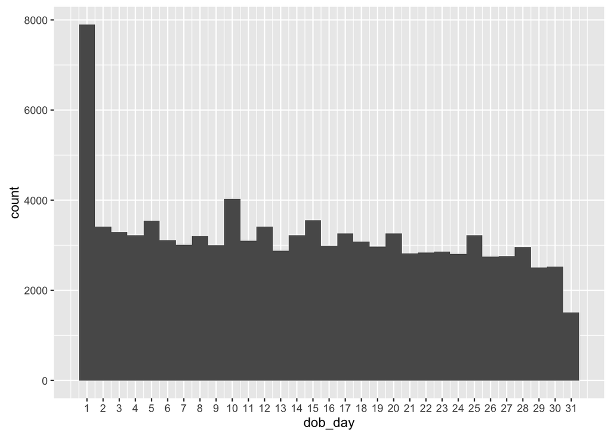

```r
library(ggplot2)

ggplot(aes(x=dob_day), data=pf) +
  geom_histogram(binwidth=1) +
  scale_x_continuous(breaks=1:31)
```

#### What are some things that you notice about this histogram?

Response: Many more people have birthdays on the first day of the month than any other day. ***

### Moira’s Investigation

Notes: Moira and some other people at Facebook did an experiment where they asked people about their perceived audience size for a given post. They found that there was a big mis-match between perceived audience size and actual audience size. ***

### Estimating Your Audience Size

Notes:

#### Think about a time when you posted a specific message or shared a photo on Facebook. What was it?

Response: Post about the struggling Alberta economy

#### How many of your friends do you think saw that post?

Response: 30

#### Think about what percent of your friends on Facebook see any posts or comments that you make in a month. What percent do you think that is?

Response: 6%

### Perceived Audience Size

Notes: Moira found that people really underestimated their audience size. People usually guessed that their audience was a quarter of what it really was.

### Faceting

Notes: facet wrap is an additional formula to qplot or ggpot that that takes a formula. The syntax is facet_wrap(~variable). This create a histogram for each variable in the facet wrap formula brackets.

Facet grid is similar to facet wrap except it spreads out the histograms over two variables. The syntax is facet_grid(vertical~horizontal).

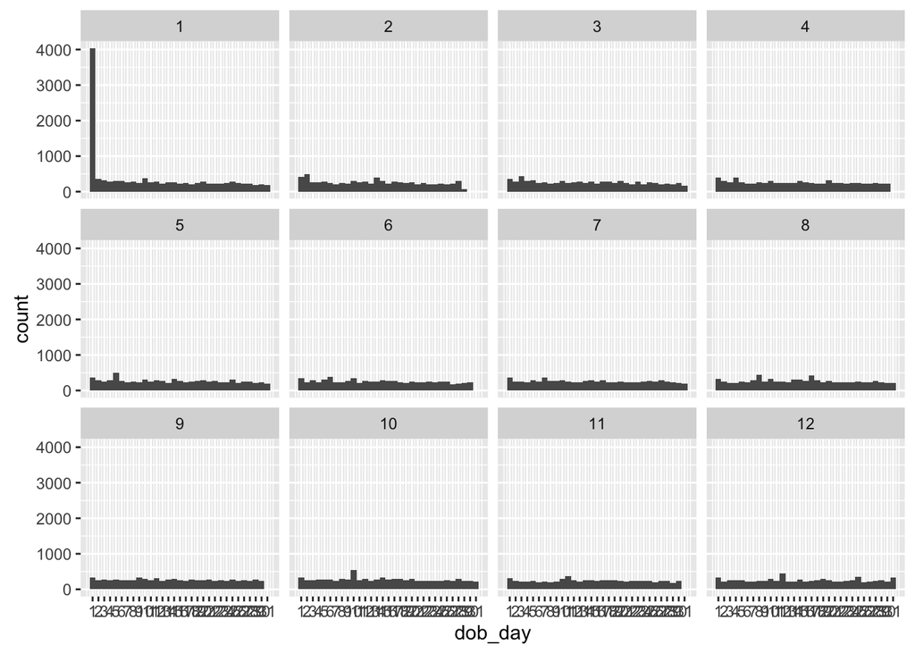

```r
ggplot(aes(x=dob_day), data=pf) +
  geom_histogram(binwidth=1) +
  scale_x_continuous(breaks=1:31) +
  facet_wrap(~dob_month)
```

#### Let’s take another look at our plot. What stands out to you here?

Response: There are a lot more birthdays on January 1 than any other day of the year. ***

### Be Skeptical - Outliers and Anomalies

Notes: Outliers and anomalies represent that there may limitations to the data or something wrong with the data collection. Sometimes data sets are top coded which means that values above a certain threshold are censored or replaced with a random value to protect identity.

Outliers can fall into a few categories: * Good data about an extreme case * Bad data about an extreme case * Bad data about a not extreme case ***

### Moira’s Outlier

Notes: #### Which case do you think applies to Moira’s outlier? Response: Moira’s outlier was bad data about an extreme case since the respondent said that 10 million people saw his/her post when that large of a number is not possible with the number of friends allowed on Facebook. ***

### Friend Count

Notes: Create histogram of friend count using ggplot or qplot. How does the histogram spread of friend count look in our information?

#### What code would you enter to create a histogram of friend counts?

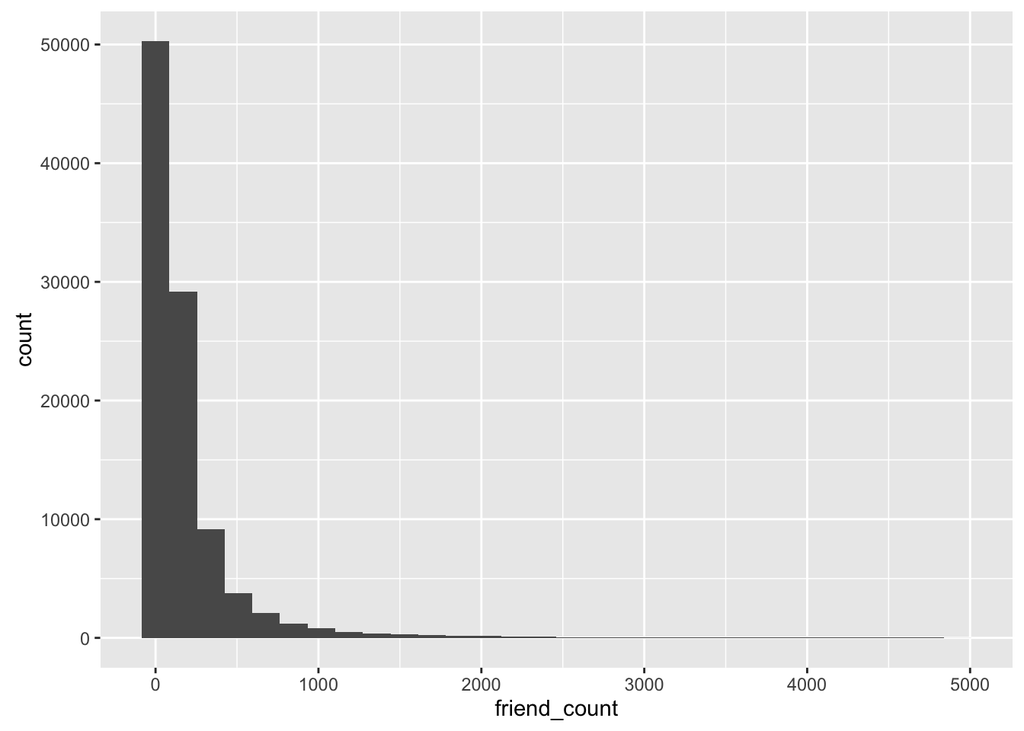

```r
ggplot(aes(x=friend_count), data=pf) +
  geom_histogram()
```

#### How is this plot similar to Moira’s first plot?

Response: The data is positively skewed and has a very long tail. The bulk of the data is on the left hand side of the graph and is hard to intepret because of the large outliers in the data set. ***

### Limiting the Axes

Notes: The axis can be limited by passing a vector in the scale_x_continuous layer using limits.

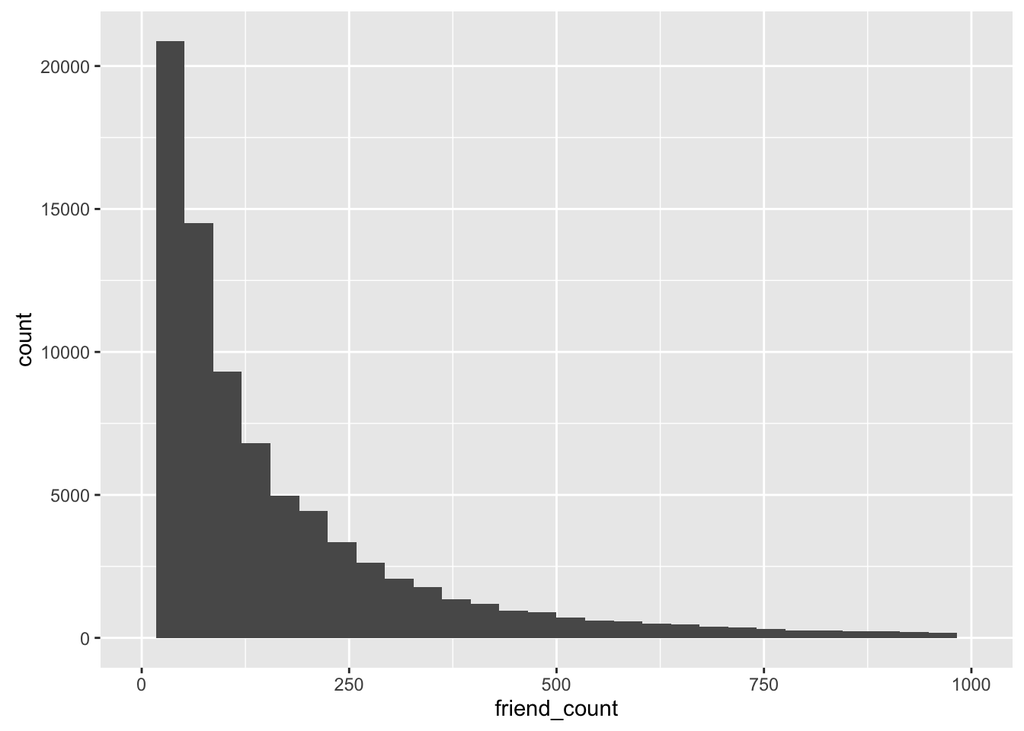

```r
ggplot(aes(x=friend_count), data = pf) +
  geom_histogram() +
  scale_x_continuous(limits = c(0,1000))
```

### Exploring with Bin Width

Notes: Specifying the bin width in the geom_histogram layer can bring out important data insights. ***

### Adjusting the Bin Width

Notes: geom_histogram(binwidth=?)

### Faceting Friend Count

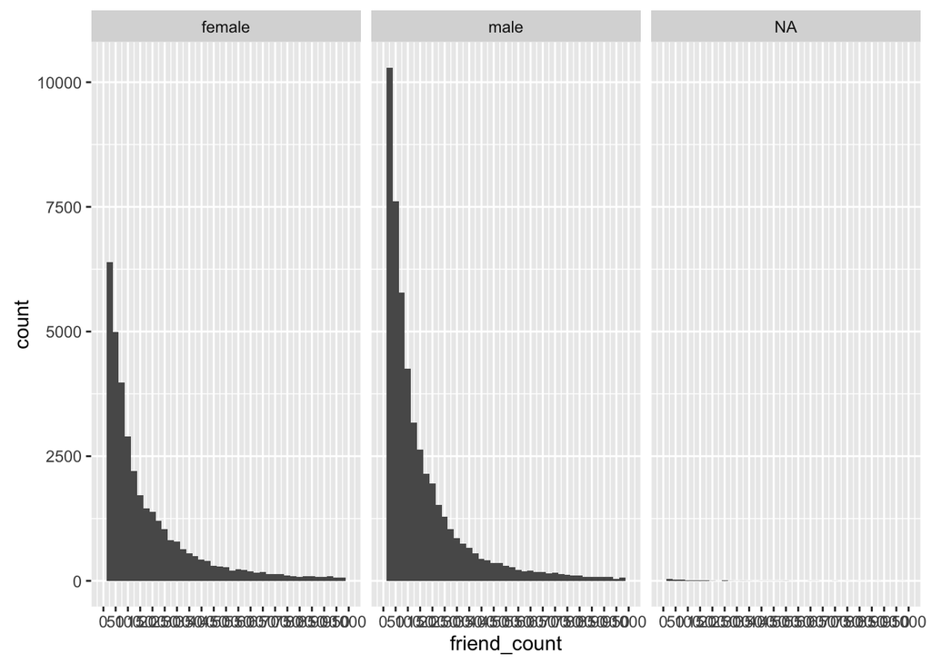

```r
# What code would you add to create a facet the histogram by gender?
# Add it to the code below.
ggplot(data=pf, aes(x=friend_count)) +
  geom_histogram(binwidth=25) +
  scale_x_continuous(limits=c(0,1000),
  breaks = seq(0,1000,50)) +
  facet_wrap(~gender)
```

### Omitting NA Values

Notes: NA can be omitted by subsetting the data and using !is.na(column) syntax. All of the data will be included except for the NA in the specific column.

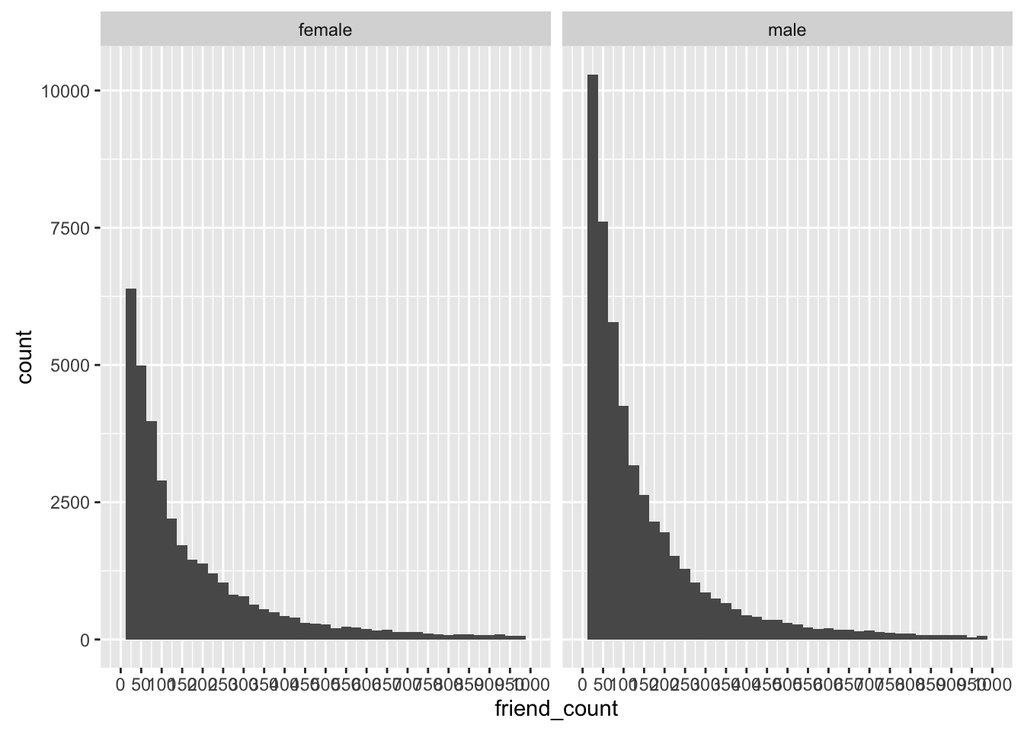

```r
ggplot(aes(x=friend_count), data=subset(pf, !is.na(gender))) +
  geom_histogram(binwidth=25) +
  scale_x_continuous(limits=c(0,1000), breaks = seq(0,1000,50)) +
  facet_wrap(~gender)
```

***

### Statistics ‘by’ Gender

Notes: The “by” function takes a varible, a categorical variable, and a function to apply to the variable.

```r
by(pf$friend_count, pf$gender, summary)
```

```
## pf$gender: female
##    Min. 1st Qu.  Median    Mean 3rd Qu.    Max.
##       0      37      96     242     244    4923
## --------------------------------------------------------
## pf$gender: male
##    Min. 1st Qu.  Median    Mean 3rd Qu.    Max.
##       0      27      74     165     182    4917
```

#### Who on average has more friends: men or women?

Response: Women

#### What’s the difference between the median friend count for women and men?

Response: 22

#### Why would the median be a better measure than the mean?

Response: An outlier can skew the mean but would have little effect on the median. ***

### Tenure

Notes: Let’s measure the tenure, the amount of time that a user has been a member of Facebook. The binwidth will be set to show the number of days.

This time we will add color to the histogram by using: geom_histogram(color=“black”, fill = “blue”)

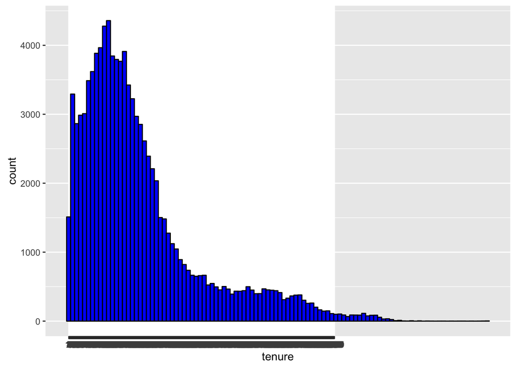

```r
ggplot(aes(x=tenure), data = pf) +
  geom_histogram(binwidth=30, color = 'black', fill = 'blue') +
  scale_x_continuous(breaks = 1:2000)
```

#### How would you create a histogram of tenure by year?

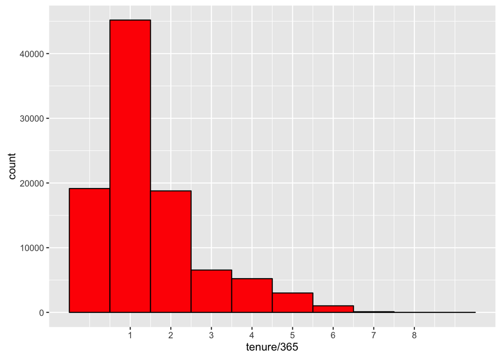

```r
ggplot(aes(tenure/365), data = pf) +
  geom_histogram(binwidth=1, color = 'black', fill = 'red') +
  scale_x_continuous(breaks=1:8)
```

***

### Labeling Plots

Notes: Add labels to the plots to make them more readable and accessible to all users. Labels are added as extra layers using xlab(“Label”) and ylab(“label”)

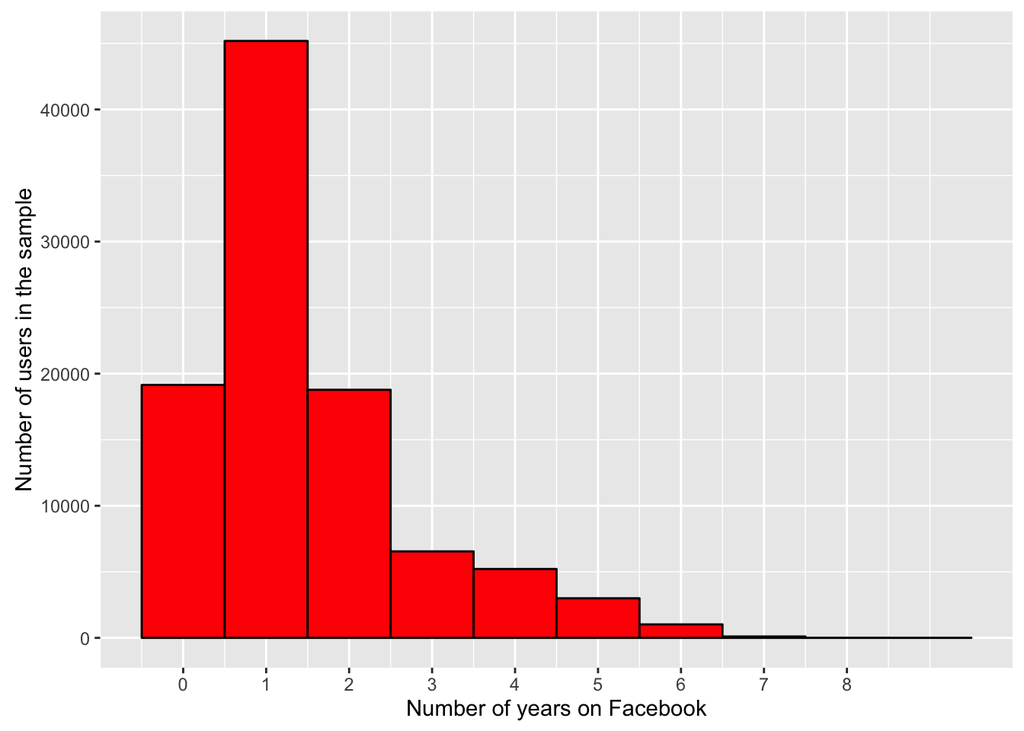

```r
ggplot(aes(tenure/365), data = pf) +
  geom_histogram(binwidth=1, color = 'black', fill = 'red') +
  scale_x_continuous(breaks=0:8) +
  xlab("Number of years on Facebook") +
  ylab("Number of users in the sample")
```

### User Ages

Notes: Create a histogram of the user’s ages.

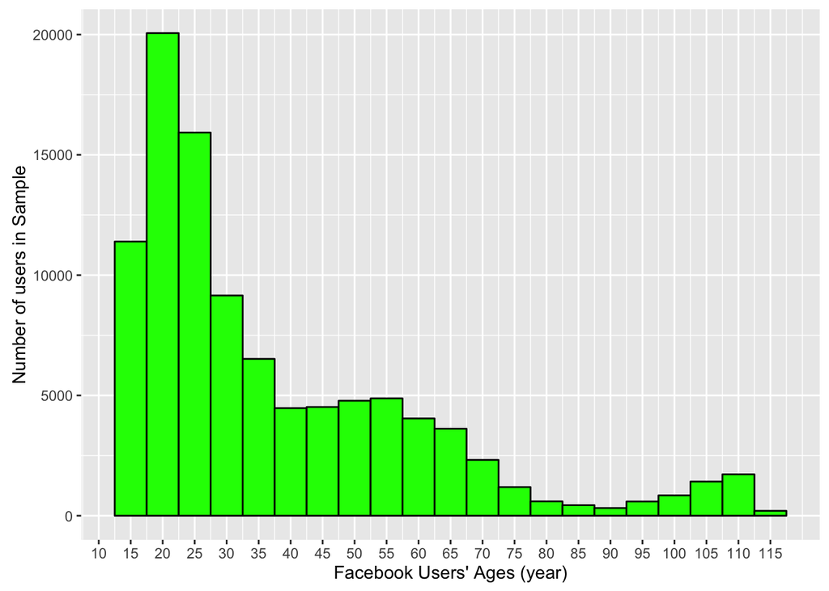

```r
ggplot(aes(x=age), data = pf) +
 geom_histogram(binwidth= 5, color = 'black', fill = 'green') +
  scale_x_continuous(breaks = seq(0,115,5)) + xlab("Facebook Users' Ages (year)") +
 ylab("Number of users in Sample")
```

### The Spread of Memes

Notes:

### Lada’s Money Bag Meme

Notes: Lada studied memes and their usage/popularity on Facebook. She plotted a ggplot on R using a log scale to see the popularity of certain memes. ***

### Transforming Data

Notes: Sometimes data is better represented on a log scale or a square root scale. This is especially the case when there are large outliers or the peaks are much larger than the majority of the data.

Data can be transformed in this way in summary statement or plot using the log10, sqrt, or any other scaling factor command.

summary(log10(pf$tenure))

scale_x_log10() for plots

grid.arrange() to show multiple plots on the same canvas.

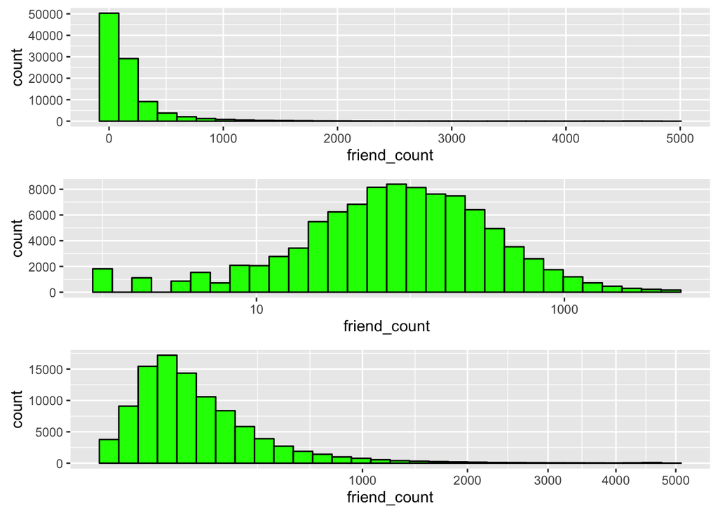

```r
library(gridExtra)
p1 = ggplot(aes(x=friend_count), data=pf) +
  geom_histogram(color='black', fill = 'green')
p2 = p1 + scale_x_log10()
p3 = p1 + scale_x_sqrt()

grid.arrange(p1, p2, p3, ncol=1)
```

### Add a Scaling Layer

Notes: Adding a scaling layer, like that done in ggplot, keeps the actual numbers instead of the logarithmic numbers. It’s more intuitive.

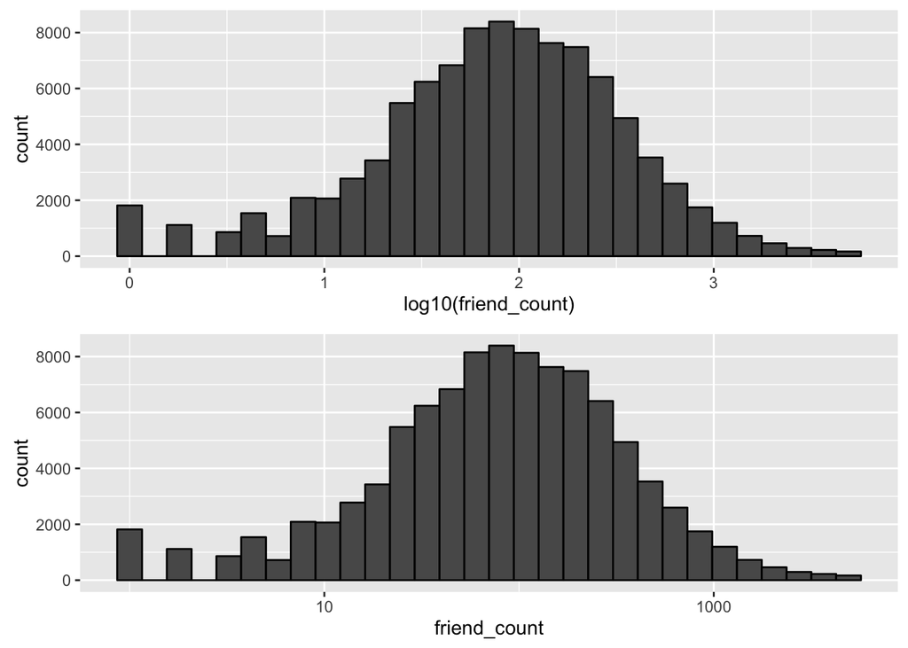

```r
q1 = ggplot(data = pf, aes(x=log10(friend_count))) +
  geom_histogram(color='black')

q2 = ggplot(data=pf, aes(x=friend_count)) +
  scale_x_log10() +
  geom_histogram(color='black')

grid.arrange(q1, q2)
```

### Frequency Polygons

Notes: Frequency polygons are like histograms except they connect the top of the histogram only and come out as line graphs.

The code to make frequency polygons is to add geom_freqpoly(aes())

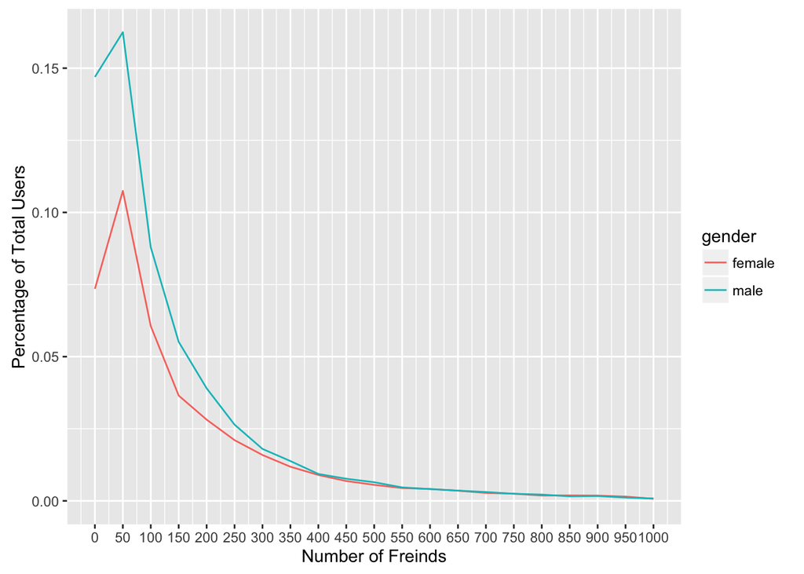

```r
ggplot(aes(x=friend_count, y=..count../sum(..count..)), data = subset(pf, !is.na(gender))) +
  geom_freqpoly(aes(color=gender), binwidth=50) +
  scale_x_continuous(limits=c(0,1000), breaks = seq(0,1000, 50)) +
  xlab('Number of Freinds') +
  ylab('Percentage of Total Users')
```

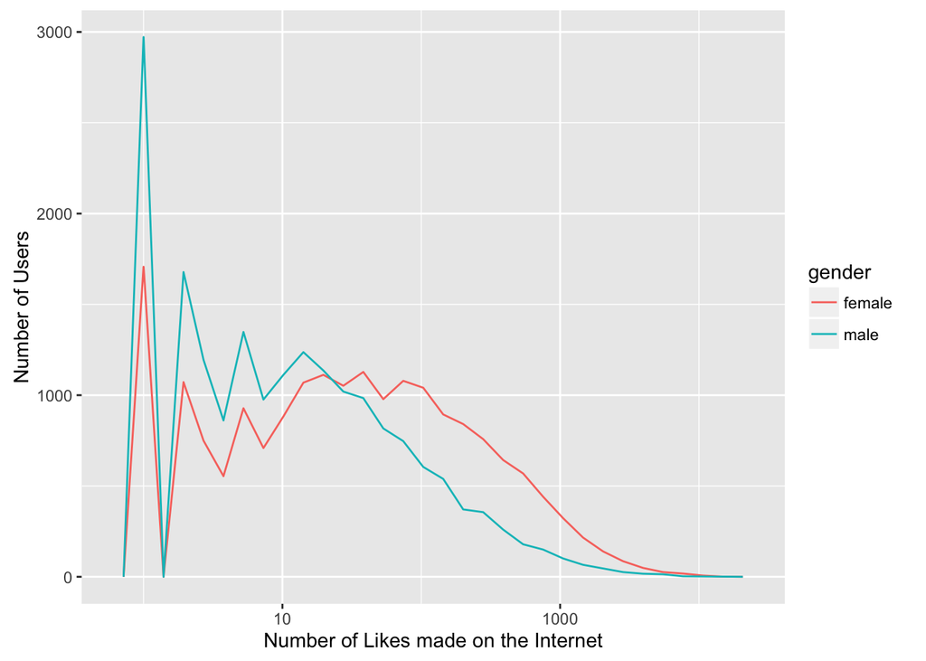

```r
ggplot(aes(x=www_likes), data=subset(pf, !is.na(gender))) +
  geom_freqpoly(aes(color=gender)) +
  scale_x_log10() +
  xlab('Number of Likes made on the Internet') +
  ylab('Number of Users')
```

***

### Likes on the Web

Notes: Which gender makes more likes on the web? Let’s find out numerically. First we will show the statistics of the likes grouped by gender.

```r
by(pf$www_likes, pf$gender, summary)
```

```
## pf$gender: female
##     Min.  1st Qu.   Median     Mean  3rd Qu.     Max.
##     0.00     0.00     0.00    87.14    25.00 14860.00
## --------------------------------------------------------
## pf$gender: male
##     Min.  1st Qu.   Median     Mean  3rd Qu.     Max.
##     0.00     0.00     0.00    24.42     2.00 12900.00
```

Then we will see the total number of likes for all males and females:

```r
by(pf$www_likes, pf$gender, sum)
```

```
## pf$gender: female
## [1] 3507665
## --------------------------------------------------------
## pf$gender: male
## [1] 1430175
```

### Box Plots

Notes: Box plots are good visualization tool for outliers and data within the interquartile range (IQR)

Box plots are created using the geom_boxplot() syntax.

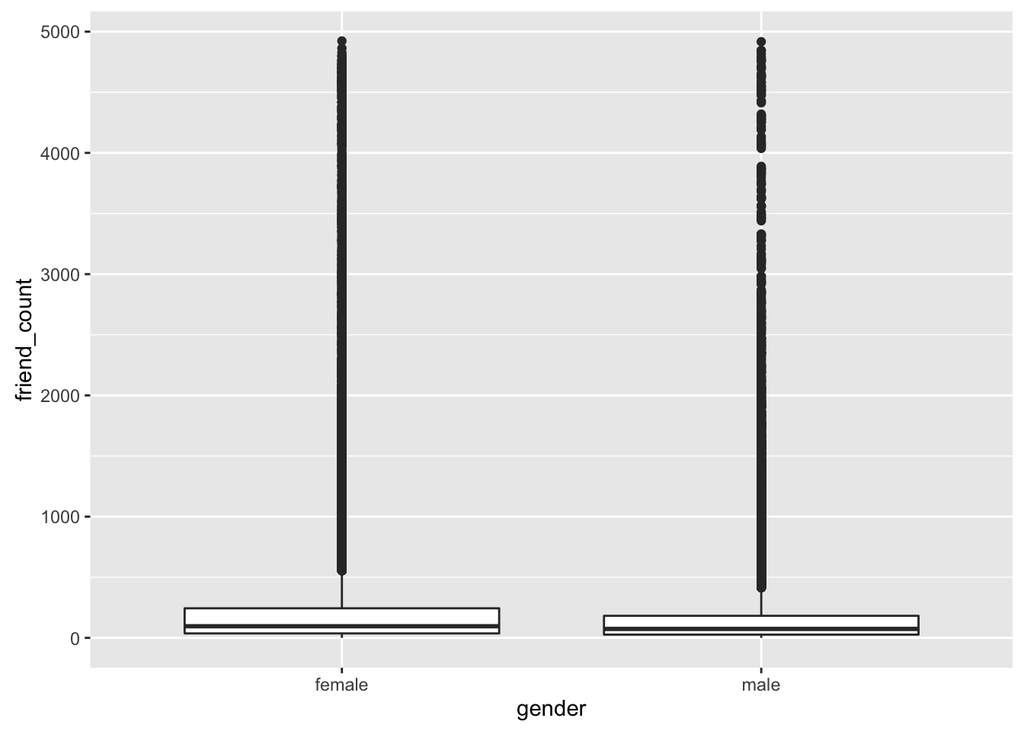

```r
ggplot(aes(x=gender, y=friend_count), data=subset(pf, !is.na(gender))) +
  geom_boxplot()
```

#### Adjust the code to focus on users who have friend counts between 0 and 1000.

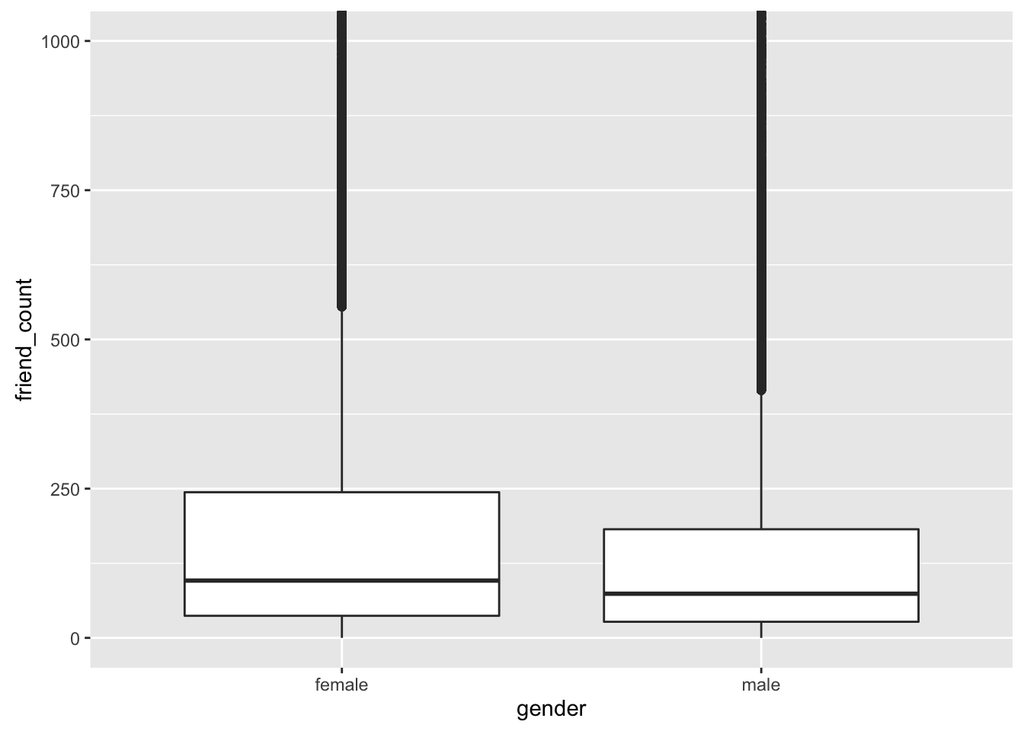

```r
ggplot(aes(x=gender, y=friend_count), data=subset(pf, !is.na(gender))) +
  geom_boxplot() +
  coord_cartesian(ylim=c(0,1000))
```

The data can be limited and still take the excluded points into the calculation by using coord_cartesian(ylim=c())

### Box Plots, Quartiles, and Friendships

Notes: The box plot is interpreted in the following way:

- The bold line in the middle is the median value of the data and the top and bottom line are the 3rd and 1st quartile, respectively.

#### On average, who initiated more friendships in our sample: men or women?

Response: Women #### Write about some ways that you can verify your answer.

Let’s use the same techniques to determine which gender initiated the most friendships.

```r
by(pf$friendships_initiated, pf$gender, summary)
```

```
## pf$gender: female
##    Min. 1st Qu.  Median    Mean 3rd Qu.    Max.
##     0.0    19.0    49.0   113.9   124.8  3654.0
## --------------------------------------------------------
## pf$gender: male
##    Min. 1st Qu.  Median    Mean 3rd Qu.    Max.
##     0.0    15.0    44.0   103.1   111.0  4144.0
```

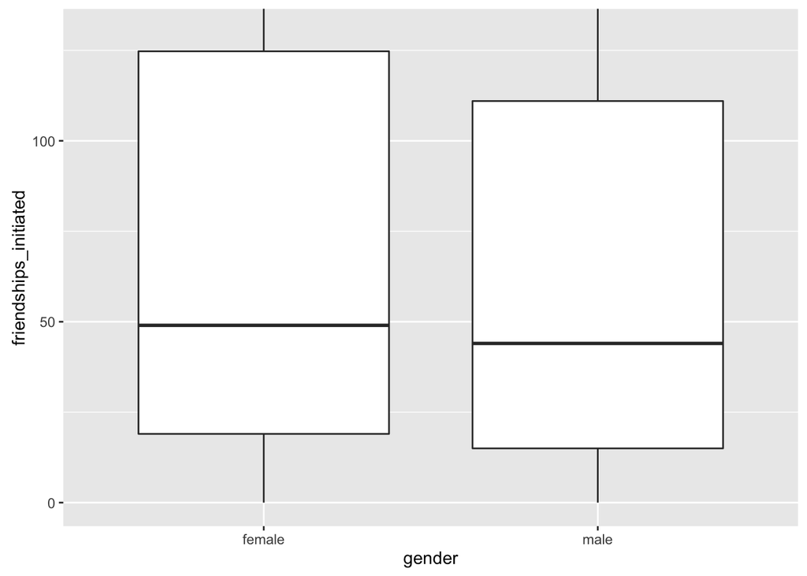

```r
ggplot(aes(x=gender, y= friendships_initiated), data=subset(pf, !is.na(gender))) +
  geom_boxplot() +
  coord_cartesian(ylim = c(0,130))
```

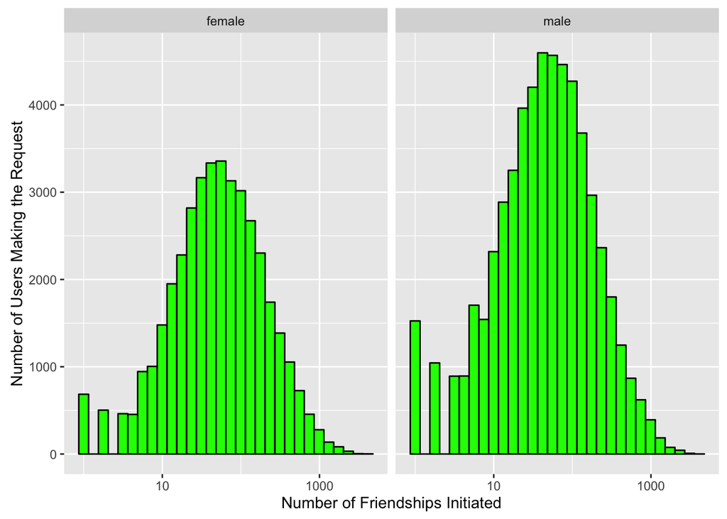

```r
ggplot(aes(x=friendships_initiated), data=subset(pf,!is.na(gender))) +
  geom_histogram(color='black', fill = 'green') +
  scale_x_log10() +
  facet_wrap(~gender) +
  xlab('Number of Friendships Initiated') +
  ylab('Number of Users Making the Request')
```

### Getting Logical

Notes: It is often useful to have logical expressions when tryin to determine the effectiveness of something. In this case, we will find out how many users use mobiles to check Facebook.

```r
pf$mobile_check <- NA

pf$mobile_check <- ifelse(pf$mobile_likes > 0, 1, 0)
pf$mobile_check <- factor(pf$mobile_check)

summary(pf$mobile_check)/length(pf$mobile_check)
```

```
##         0         1
## 0.3540903 0.6459097
```

Response:

### Analyzing One Variable

Reflection: Making histograms, frequency polygons, and box plots to visualize a large dataset can be very helpful in doing EDA.

We should also explore a new dataset by looking at it’s basic statistics: str(dataset) summary(dataset) row.names(dataset) nrow(dataset) ncol(dataset) names(dataset)

Look at the individual variables in the dataset to see what information is available.

Discover hidden patterns in the data by transforming the plots, either log or square root, or zoom in to specific things that seem interesting. ***

Click **KnitHTML** to see all of your hard work and to have an html page of this lesson, your answers, and your notes!